# Risk Factor Analysis

## Outcome Variable

**Outcome Variable:** ever_swasted

## Predictor Variables

**Intervention Variable:** fhtcm

**Adjustment Set:**

- arm
- W_mage
- W_fage
- meducyrs
- feducyrs
- W_mhtcm
- W_mwtkg
- W_mbmi
- single
- delta_W_mage
- delta_W_fage
- delta_meducyrs
- delta_feducyrs
- delta_W_mhtcm
- delta_W_mwtkg
- delta_W_mbmi
- delta_single

## Stratifying Variables

The analysis was stratified on these variable(s):

- agecat
- studyid
- country

## Data Summary

| agecat | studyid | country | fhtcm | ever_swasted | n_cell | n |
| --- | --- | --- | --- | --- | --- | --- |
| 0-24 months | COHORTS | GUATEMALA | >=167 cm | 0 | 61 | 495 |
| 0-24 months | COHORTS | GUATEMALA | >=167 cm | 1 | 2 | 495 |
| 0-24 months | COHORTS | GUATEMALA | <162 cm | 0 | 273 | 495 |
| 0-24 months | COHORTS | GUATEMALA | <162 cm | 1 | 20 | 495 |
| 0-24 months | COHORTS | GUATEMALA | [162-167) cm | 0 | 130 | 495 |
| 0-24 months | COHORTS | GUATEMALA | [162-167) cm | 1 | 9 | 495 |
| 0-24 months | Keneba | GAMBIA | >=167 cm | 0 | 1012 | 1933 |
| 0-24 months | Keneba | GAMBIA | >=167 cm | 1 | 236 | 1933 |
| 0-24 months | Keneba | GAMBIA | <162 cm | 0 | 99 | 1933 |
| 0-24 months | Keneba | GAMBIA | <162 cm | 1 | 33 | 1933 |
| 0-24 months | Keneba | GAMBIA | [162-167) cm | 0 | 454 | 1933 |
| 0-24 months | Keneba | GAMBIA | [162-167) cm | 1 | 99 | 1933 |
| 0-24 months | PROBIT | BELARUS | >=167 cm | 0 | 10716 | 12537 |
| 0-24 months | PROBIT | BELARUS | >=167 cm | 1 | 1028 | 12537 |
| 0-24 months | PROBIT | BELARUS | <162 cm | 0 | 153 | 12537 |
| 0-24 months | PROBIT | BELARUS | <162 cm | 1 | 15 | 12537 |
| 0-24 months | PROBIT | BELARUS | [162-167) cm | 0 | 573 | 12537 |
| 0-24 months | PROBIT | BELARUS | [162-167) cm | 1 | 52 | 12537 |
| 0-24 months | SAS-CompFeed | INDIA | >=167 cm | 0 | 357 | 895 |
| 0-24 months | SAS-CompFeed | INDIA | >=167 cm | 1 | 50 | 895 |
| 0-24 months | SAS-CompFeed | INDIA | <162 cm | 0 | 195 | 895 |
| 0-24 months | SAS-CompFeed | INDIA | <162 cm | 1 | 31 | 895 |
| 0-24 months | SAS-CompFeed | INDIA | [162-167) cm | 0 | 221 | 895 |
| 0-24 months | SAS-CompFeed | INDIA | [162-167) cm | 1 | 41 | 895 |
| 0-24 months | SAS-FoodSuppl | INDIA | >=167 cm | 0 | 91 | 399 |
| 0-24 months | SAS-FoodSuppl | INDIA | >=167 cm | 1 | 15 | 399 |
| 0-24 months | SAS-FoodSuppl | INDIA | <162 cm | 0 | 131 | 399 |
| 0-24 months | SAS-FoodSuppl | INDIA | <162 cm | 1 | 32 | 399 |
| 0-24 months | SAS-FoodSuppl | INDIA | [162-167) cm | 0 | 110 | 399 |
| 0-24 months | SAS-FoodSuppl | INDIA | [162-167) cm | 1 | 20 | 399 |

The following strata were considered:

- agecat: 0-24 months, studyid: COHORTS, country: GUATEMALA
- agecat: 0-24 months, studyid: Keneba, country: GAMBIA
- agecat: 0-24 months, studyid: PROBIT, country: BELARUS
- agecat: 0-24 months, studyid: SAS-CompFeed, country: INDIA
- agecat: 0-24 months, studyid: SAS-FoodSuppl, country: INDIA

### Dropped Strata

Some strata were dropped due to rare outcomes:

- agecat: 0-24 months, studyid: COHORTS, country: GUATEMALA

## Methods Detail

We're interested in the causal parameters $E[Y_a]$ for all values of $a \in \mathcal{A}$. These parameters represent the mean outcome if, possibly contrary to fact, we intervened to set all units to have $A=a$. Under the randomization and positivity assumptions, these are identified by the statistical parameters $\psi_a=E_W[E_{Y|A,W}(Y|A=a,W)]$. In addition, we're interested in the mean of $Y$, $E[Y]$ under no intervention (the observed mean). We will estimate these parameters by using SuperLearner to fit the relevant likelihood factors -- $E_{Y|A,W}(Y|A=a,W)$ and $p(A=a|W)$, and then updating our likelihood fit using a joint TMLE.

For unadjusted analyses ($W=\{\}$), initial likelihoods were estimated using Lrnr_glm to estimate the simple $E(Y|A)$ and Lrnr_mean to estimate $p(A)$. For adjusted analyses, a small library containing Lrnr_glmnet, Lrnr_xgboost, and Lrnr_mean was used.

Having estimated these parameters, we will then use the delta method to estimate relative risks and attributable risks relative to a prespecified baseline level of $A$.

# Results Detail

## Results Plots

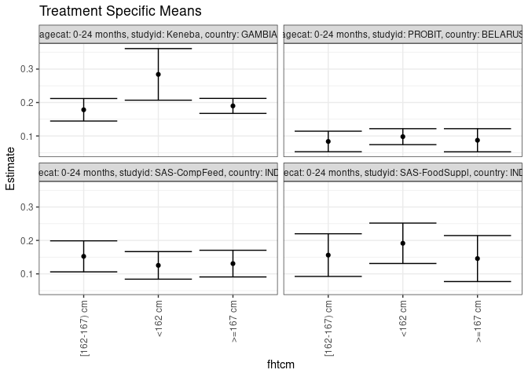

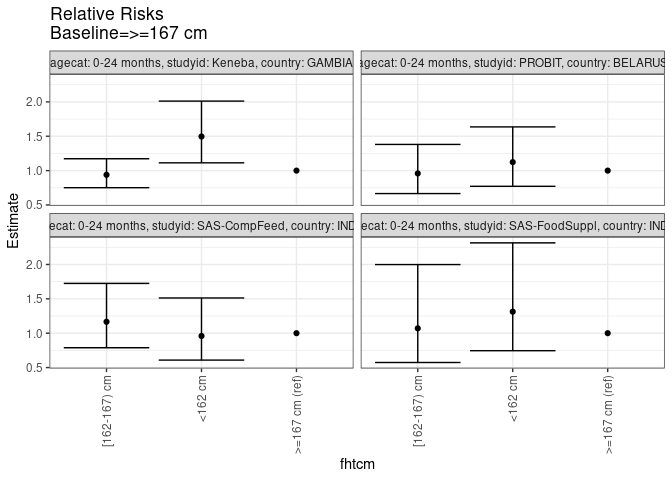

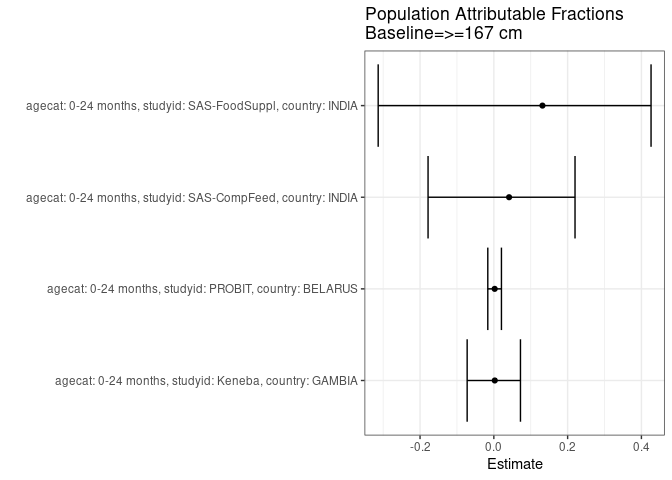

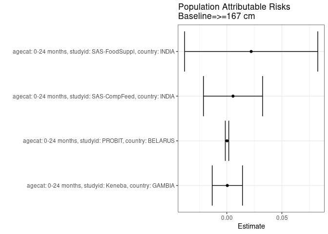

## Results Table

### Parameter: TSM

| agecat | studyid | country | intervention_level | baseline_level | estimate | ci_lower | ci_upper |
| --- | --- | --- | --- | --- | --- | --- | --- |
| 0-24 months | Keneba | GAMBIA | >=167 cm | NA | 0.1898962 | 0.1675199 | 0.2122726 |
| 0-24 months | Keneba | GAMBIA | <162 cm | NA | 0.2841507 | 0.2069847 | 0.3613166 |
| 0-24 months | Keneba | GAMBIA | [162-167) cm | NA | 0.1782980 | 0.1446475 | 0.2119486 |
| 0-24 months | PROBIT | BELARUS | >=167 cm | NA | 0.0871415 | 0.0525157 | 0.1217674 |
| 0-24 months | PROBIT | BELARUS | <162 cm | NA | 0.0979027 | 0.0740373 | 0.1217681 |
| 0-24 months | PROBIT | BELARUS | [162-167) cm | NA | 0.0835702 | 0.0528594 | 0.1142810 |
| 0-24 months | SAS-CompFeed | INDIA | >=167 cm | NA | 0.1306765 | 0.0907730 | 0.1705800 |
| 0-24 months | SAS-CompFeed | INDIA | <162 cm | NA | 0.1254014 | 0.0841775 | 0.1666253 |
| 0-24 months | SAS-CompFeed | INDIA | [162-167) cm | NA | 0.1523790 | 0.1059857 | 0.1987723 |
| 0-24 months | SAS-FoodSuppl | INDIA | >=167 cm | NA | 0.1457911 | 0.0769877 | 0.2145945 |
| 0-24 months | SAS-FoodSuppl | INDIA | <162 cm | NA | 0.1914413 | 0.1310254 | 0.2518572 |
| 0-24 months | SAS-FoodSuppl | INDIA | [162-167) cm | NA | 0.1561151 | 0.0923242 | 0.2199061 |

### Parameter: E(Y)

| agecat | studyid | country | intervention_level | baseline_level | estimate | ci_lower | ci_upper |
| --- | --- | --- | --- | --- | --- | --- | --- |
| 0-24 months | Keneba | GAMBIA | NA | NA | 0.1903777 | 0.1728714 | 0.2078839 |
| 0-24 months | PROBIT | BELARUS | NA | NA | 0.0873415 | 0.0532447 | 0.1214382 |
| 0-24 months | SAS-CompFeed | INDIA | NA | NA | 0.1363128 | 0.1083079 | 0.1643178 |
| 0-24 months | SAS-FoodSuppl | INDIA | NA | NA | 0.1679198 | 0.1311966 | 0.2046430 |

### Parameter: RR

| agecat | studyid | country | intervention_level | baseline_level | estimate | ci_lower | ci_upper |
| --- | --- | --- | --- | --- | --- | --- | --- |
| 0-24 months | Keneba | GAMBIA | >=167 cm | >=167 cm | 1.0000000 | 1.0000000 | 1.000000 |
| 0-24 months | Keneba | GAMBIA | <162 cm | >=167 cm | 1.4963470 | 1.1129382 | 2.011841 |
| 0-24 months | Keneba | GAMBIA | [162-167) cm | >=167 cm | 0.9389235 | 0.7516040 | 1.172928 |
| 0-24 months | PROBIT | BELARUS | >=167 cm | >=167 cm | 1.0000000 | 1.0000000 | 1.000000 |
| 0-24 months | PROBIT | BELARUS | <162 cm | >=167 cm | 1.1234908 | 0.7715795 | 1.635906 |
| 0-24 months | PROBIT | BELARUS | [162-167) cm | >=167 cm | 0.9590172 | 0.6660335 | 1.380883 |
| 0-24 months | SAS-CompFeed | INDIA | >=167 cm | >=167 cm | 1.0000000 | 1.0000000 | 1.000000 |
| 0-24 months | SAS-CompFeed | INDIA | <162 cm | >=167 cm | 0.9596323 | 0.6086986 | 1.512890 |
| 0-24 months | SAS-CompFeed | INDIA | [162-167) cm | >=167 cm | 1.1660781 | 0.7883882 | 1.724706 |
| 0-24 months | SAS-FoodSuppl | INDIA | >=167 cm | >=167 cm | 1.0000000 | 1.0000000 | 1.000000 |
| 0-24 months | SAS-FoodSuppl | INDIA | <162 cm | >=167 cm | 1.3131210 | 0.7450364 | 2.314366 |
| 0-24 months | SAS-FoodSuppl | INDIA | [162-167) cm | >=167 cm | 1.0708141 | 0.5737654 | 1.998452 |

### Parameter: PAR

| agecat | studyid | country | intervention_level | baseline_level | estimate | ci_lower | ci_upper |
| --- | --- | --- | --- | --- | --- | --- | --- |
| 0-24 months | Keneba | GAMBIA | >=167 cm | NA | 0.0004814 | -0.0132598 | 0.0142226 |
| 0-24 months | PROBIT | BELARUS | >=167 cm | NA | 0.0001999 | -0.0013891 | 0.0017890 |
| 0-24 months | SAS-CompFeed | INDIA | >=167 cm | NA | 0.0056364 | -0.0212301 | 0.0325028 |
| 0-24 months | SAS-FoodSuppl | INDIA | >=167 cm | NA | 0.0221287 | -0.0383286 | 0.0825860 |

### Parameter: PAF

| agecat | studyid | country | intervention_level | baseline_level | estimate | ci_lower | ci_upper |
| --- | --- | --- | --- | --- | --- | --- | --- |
| 0-24 months | Keneba | GAMBIA | >=167 cm | NA | 0.0025287 | -0.0723286 | 0.0721604 |
| 0-24 months | PROBIT | BELARUS | >=167 cm | NA | 0.0022891 | -0.0163754 | 0.0206110 |
| 0-24 months | SAS-CompFeed | INDIA | >=167 cm | NA | 0.0413487 | -0.1782904 | 0.2200460 |
| 0-24 months | SAS-FoodSuppl | INDIA | >=167 cm | NA | 0.1317815 | -0.3134851 | 0.4261043 |